# Lab 5: Moran’s I and LISA

2023-11-28

# Section A. Set-up

The objective of this lab is to introduce you to the concept of Voronoi polygons, Moran’s I and LISA; building on Lab 4 to look at air pollution in California.

## Libraries

Make sure to install any additional libraries you need

```r
library(tmap)
library(raster)
library(gstat)
library(sf)
library(tidyverse)
library(tigris)
library(plotly)
library(terra)
library(spdep)
```

# Section B - Voronoi Polygons

You should be able to simply run this code. If not, ask Harman or Dr G.

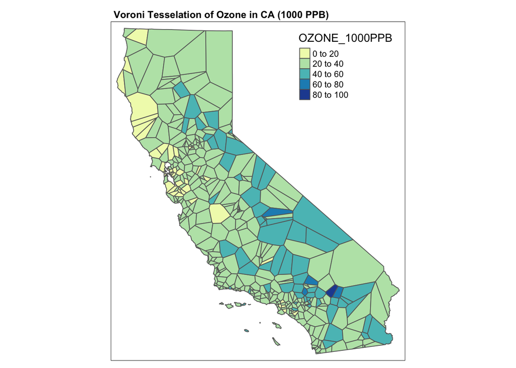

```r
# you should be able to simply run this code
ozone.terra      <- vect(ozone.sf)
ozone.voronoi.sf <- voronoi(ozone.terra)
ozone.voronoi.sf <- st_as_sf(crop(ozone.voronoi.sf,state.border.terra))

tm_shape(ozone.voronoi.sf) +
               tm_polygons("OZONE_1000PPB",palette="YlGnBu")+
               tm_legend(position = c("right", "top"))+
               tm_layout(main.title="Voroni Tesselation of Ozone in CA (1000 PPB)",
                         main.title.size=.8,main.title.fontface=2)
```

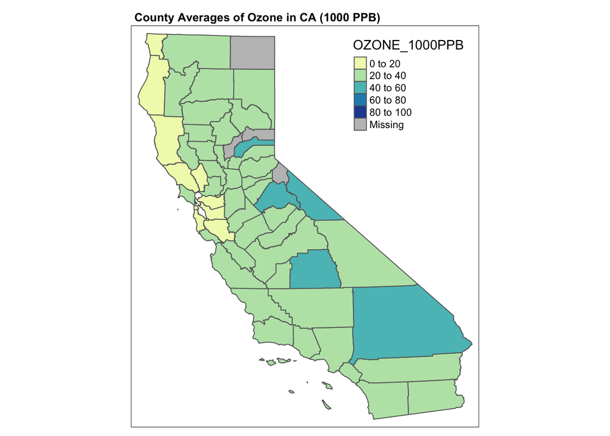

```r
tm_shape(county.data.sf) +
               tm_polygons("OZONE_1000PPB",palette="YlGnBu",breaks=seq(0,100,by=20))+
               tm_legend(position = c("right", "top"))+
               tm_layout(main.title="County Averages of Ozone in CA (1000 PPB)",
                         main.title.size=.8,main.title.fontface=2)
```

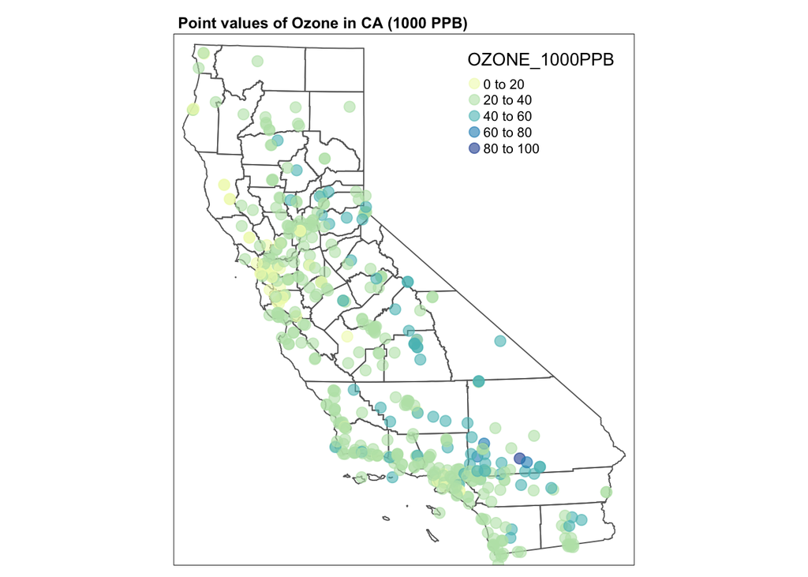

```r
tm_shape(county.data.sf) +
               tm_borders()+
               tm_shape(ozone.sf) +
               tm_dots(col="OZONE_1000PPB",palette="YlGnBu",size=.4,alpha=.6)+
               tm_legend(position = c("right", "top"))+
               tm_layout(main.title="Point values of Ozone in CA (1000 PPB)",
                         main.title.size=.8,main.title.fontface=2)
```

## Comprehension

In your own words, describe what each map is showing and what voronoi polygons are. Compare and contrast the three maps and explain the advantages and disadvantages of using each way to visualize the ozone data.

# Section C. Moran’s I tutorial

There is an excellent tutorial on Moran’s I created by Dr Manny Gimond here on incomes in Maine. We will also be working through this in class.

https://mgimond.github.io/simple_moransI_example/

I want you to work through the tutorial and get the code working here. (You do not have to do the Florida homicides bit).

IN YOUR OWN WORDS, I also want as many comments as you can following along in the text, e.g. make yourself a tutorial to explain what is happening.

# Section D. Moran’s I ozone

Here I have provided a shortened version of the code in Dr Gimond’s tutorial. My code is set to look at the ozone levels. Get it running.

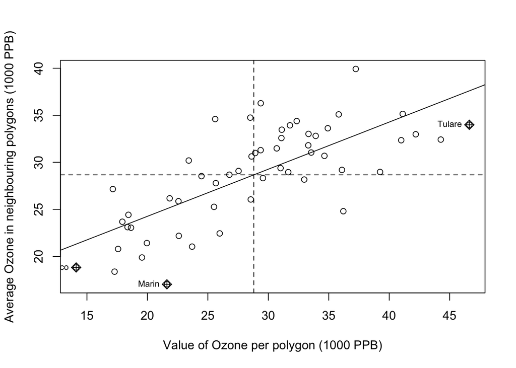

```r
# Choose the data you want.  To help your comprehension,
# Switch between this and ozone.voronoi.sf & see how it changes
moran.data <- county.data.sf

# R hates empty polygons, so we're removing them
moran.data <- moran.data[moran.data$OZONE_1000PPB >  0 , ]
tracts_empty  <- st_is_empty(moran.data)
moran.data <- moran.data[which(tracts_empty==FALSE), ]

# make the nearest neighbours and weights matrix
nb <- poly2nb(moran.data, queen=TRUE)
lw <- nb2listw(nb, style="W", zero.policy=TRUE)

# Make the moran scatter plot
moran.plot(moran.data$OZONE_1000PPB,
           labels=as.character(moran.data$COUNTY),
           listw= lw,
           xlab = "Value of Ozone per polygon (1000 PPB)",
           ylab = "Average Ozone in neighbouring polygons (1000 PPB)",
           zero.policy = T)
```

```r
# And conduct the moran hypothesis test
moran.test(moran.data$OZONE_1000PPB, listw= lw)
```

```
##
##  Moran I test under randomisation
##
## data:  moran.data$OZONE_1000PPB
## weights: lw
##
## Moran I statistic standard deviate = 5.7038, p-value = 5.858e-09
## alternative hypothesis: greater
## sample estimates:
## Moran I statistic       Expectation          Variance
##       0.500936524      -0.018867925       0.008305187
```

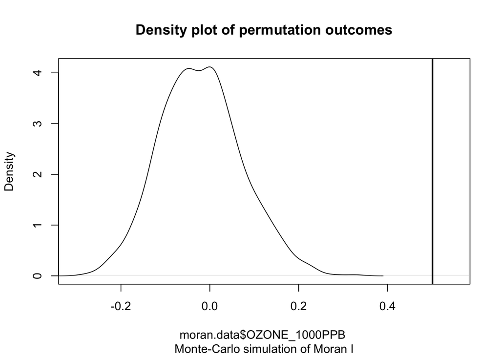

```r
plot(moran.mc(moran.data$OZONE_1000PPB, lw, nsim=999, alternative="greater"))
```

## Interpretation

interpret what I found in the moran’s scatterplot, test and histogram in your own words. Please include a full Moran’s I hypothesis test in your write up (e.g. H0, H1, the test statistic, the p-value and your interpretation)

## Monte Carlo

In your own words, explain the difference between a Monte Carlo approach and a theoretical approach to the hypothesis test.

## A different variable

Then, copy and edit my code to conduct a Moran’s I analysis of a variable (column) of your choice and interpret your findings in the text. Remember, you can go back to the lab 4 description to work out what columns are showing you - and names(moran.data) will show you the column names.

# Section E. LISA

My code for the LISA analysis should just run. I have split it into several code chunks to make it easier for the cloud and to explain what is happening. Get them all running then see below for questions.

```r
#---------------------------------------------------
# We can either create the Raw LISA values using the theoretical approach or Monte Carlo
#
#  - Padjust allows us to account for mulitple testing issues.
#  - adjust.x allows us to omit polygons with no neighbours as needed
#  - zero.policy allows us to keep but ignore polygons with no neighbours
#  - nsim: number of simulations, If this crashes the cloud try reducing to say 50
#---------------------------------------------------
LocalMoran_Output <- localmoran_perm(x = moran.data$OZONE_1000PPB,
                                     listw = lw,
                                     nsim=499,
                                     adjust.x = TRUE,
                                     zero.policy = T)
```

```r
#---------------------------------------------------
# The column names are less intuitive to newbies, so let's rename them
# (to see the originals, type ?localmoran into the console)
# The skew and kurtosis are because the histogram of IRP I might not look normal
# To do this I force the output to be a standard dataframe
#---------------------------------------------------
LocalMoran_Table <- as.data.frame(LocalMoran_Output)
names(LocalMoran_Table) <- c("Observed_LocalI", "IRP_estimate_LocalI",   "Variance_I",
                             "ZScore_I",  "PValue_Theoretical",  "PValue_MonteCarlo",
                             "Skew_I","Kurtosis_I")

#---------------------------------------------------
# Merge with our data
#---------------------------------------------------
moran.data <- cbind(moran.data,LocalMoran_Table[,4:6])

#---------------------------------------------------
# It turns out that the quadrants are secretly stored in the output,
# so we don't even have to manually calculate them
#---------------------------------------------------
moran.data$LISA_Quadrant <- attr(LocalMoran_Output,"quadr")$mean
```

```r
#---------------------------------------------------
# Remove polygons that are unlikely to be significant
# YOU GET TO CHOOSE THE THRESHOLD HERE
# Find the rows where your p-value is > your threshold
#---------------------------------------------------
critical_threshold <- 0.05
RowsOverThreshold <- which(moran.data$PValue_MonteCarlo > critical_threshold)

#---------------------------------------------------
# Make the column a character to make life easy
# Then rename the quadrant in those rows p>0.05, or
# whatever your threshold is
#---------------------------------------------------
moran.data$LISA_Quadrant_Plot <- as.character(moran.data$LISA_Quadrant)
moran.data$LISA_Quadrant_Plot[RowsOverThreshold] <- paste("P>",critical_threshold,sep="")
```

```r
#---------------------------------------------------
# Make a factor again
#---------------------------------------------------
moran.data$LISA_Quadrant_Plot <- factor(moran.data$LISA_Quadrant_Plot,
                               levels= c("High-High","High-Low",
                                         "Low-High", "Low-Low",
                                         paste("P>",critical_threshold,sep="")))
```

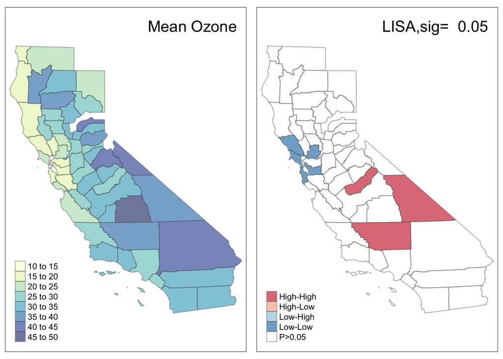

```r
#---------------------------------------------------
# And make a plot
#---------------------------------------------------
mapLISA <-
  tm_shape(moran.data)  +
  tm_fill( "LISA_Quadrant_Plot",id="NAME",  alpha=.6,
           palette=  c("#ca0020","#f4a582","#92c5de","#0571b0","white"), title="") +
  tm_borders(alpha=.5) +
  tm_legend(position = c("left", "bottom"))+
  tm_layout(title = paste("LISA,sig= ",critical_threshold), title.position = c("right", "top"))


#---------------------------------------------------
# compare against the raw values
#---------------------------------------------------
mapRaw <- tm_shape(moran.data) +
  tm_fill(col = "OZONE_1000PPB",
              style = "pretty",
              palette = "YlGnBu",
              border.alpha = 0,
              title = "",alpha=.6) +
  tm_layout(title = "Mean Ozone", title.position = c("right", "top"))+
  tm_borders(alpha=.5)+
  tm_legend(position = c("left", "bottom"))



tmap_options(check.and.fix = TRUE)
tmap_mode("plot")
tmap_arrange(mapRaw,mapLISA)
```

## Interpretation

Using the lecture notes and readings interpret what the maps are showing you. Your write up should include

- What do each of the four colors/quadrants mean
- How do they link to the Moran scatterplot

## P values

Change the critical threshold to 0.01, and to 0.1 and to 0.5. Each time, re-run the LISA code (everything including and below the critical code chunk, or run-all). Explain what is happening in terms of ozone pollution in California.